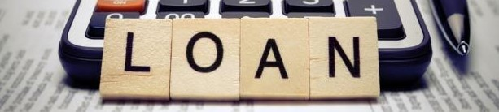

# Loan Prediction

```python
import pandas as pd
import numpy as np
import matplotlib.pyplot as plt
import seaborn as sns
```

```python
data = pd.read_csv('Dataset.csv')
```

```python
data
```

|  | Loan_ID | Gender | Married | Dependents | Education | Self_Employed | ApplicantIncome | CoapplicantIncome | LoanAmount | Loan_Amount_Term | Credit_History | Property_Area | Loan_Status |
| --- | --- | --- | --- | --- | --- | --- | --- | --- | --- | --- | --- | --- | --- |
| 0 | LP001002 | Male | No | 0 | Graduate | No | 5849 | 0.0 | NaN | 360.0 | 1.0 | Urban | Y |
| 1 | LP001003 | Male | Yes | 1 | Graduate | No | 4583 | 1508.0 | 128.0 | 360.0 | 1.0 | Rural | N |
| 2 | LP001005 | Male | Yes | 0 | Graduate | Yes | 3000 | 0.0 | 66.0 | 360.0 | 1.0 | Urban | Y |
| 3 | LP001006 | Male | Yes | 0 | Not Graduate | No | 2583 | 2358.0 | 120.0 | 360.0 | 1.0 | Urban | Y |
| 4 | LP001008 | Male | No | 0 | Graduate | No | 6000 | 0.0 | 141.0 | 360.0 | 1.0 | Urban | Y |
| ... | ... | ... | ... | ... | ... | ... | ... | ... | ... | ... | ... | ... | ... |
| 609 | LP002978 | Female | No | 0 | Graduate | No | 2900 | 0.0 | 71.0 | 360.0 | 1.0 | Rural | Y |
| 610 | LP002979 | Male | Yes | 3+ | Graduate | No | 4106 | 0.0 | 40.0 | 180.0 | 1.0 | Rural | Y |
| 611 | LP002983 | Male | Yes | 1 | Graduate | No | 8072 | 240.0 | 253.0 | 360.0 | 1.0 | Urban | Y |
| 612 | LP002984 | Male | Yes | 2 | Graduate | No | 7583 | 0.0 | 187.0 | 360.0 | 1.0 | Urban | Y |
| 613 | LP002990 | Female | No | 0 | Graduate | Yes | 4583 | 0.0 | 133.0 | 360.0 | 0.0 | Semiurban | N |

614 rows × 13 columns

```python
data.isnull().sum()
```

```
Loan_ID               0
Gender               13
Married               3
Dependents           15
Education             0
Self_Employed        32
ApplicantIncome       0
CoapplicantIncome     0
LoanAmount           22
Loan_Amount_Term     14
Credit_History       50
Property_Area         0
Loan_Status           0
dtype: int64
```

```python
# Before treating missinf values, we convert categorical values
```

```python
data.Loan_Status = data.Loan_Status.map({'Y' : 1, 'N' : 0})
```

```python
print('Column Name\tNo. of Unique values\tUnique Values')
for i in data.columns[[1,2,3,4,5,9,10,11,12]]:
    print(i,'\t\t',len(data[str(i)].unique()),'\t\t', data[str(i)].unique())
```

```
Column Name	No. of Unique values	Unique Values
Gender 		 3 		 ['Male' 'Female' nan]
Married 		 3 		 ['No' 'Yes' nan]
Dependents 		 5 		 ['0' '1' '2' '3+' nan]
Education 		 2 		 ['Graduate' 'Not Graduate']
Self_Employed 		 3 		 ['No' 'Yes' nan]
Loan_Amount_Term 		 11 		 [360. 120. 240.  nan 180.  60. 300. 480.  36.  84.  12.]
Credit_History 		 3 		 [ 1.  0. nan]
Property_Area 		 3 		 ['Urban' 'Rural' 'Semiurban']
Loan_Status 		 2 		 [1 0]
```

```python
data.Gender.replace(np.nan,'Others', inplace = True)
data.Married.replace(np.nan,'Others', inplace = True)
data.Dependents.replace(np.nan,'Others', inplace = True)
data.Self_Employed.replace(np.nan,'Others', inplace = True)
data.Loan_Amount_Term.replace(np.nan,'Others', inplace = True)
data.Credit_History.replace(np.nan,'Others', inplace = True)
```

```python
data.isnull().sum()
```

```
Loan_ID               0
Gender                0
Married               0
Dependents            0
Education             0
Self_Employed         0
ApplicantIncome       0
CoapplicantIncome     0
LoanAmount           22
Loan_Amount_Term      0
Credit_History        0
Property_Area         0
Loan_Status           0
dtype: int64
```

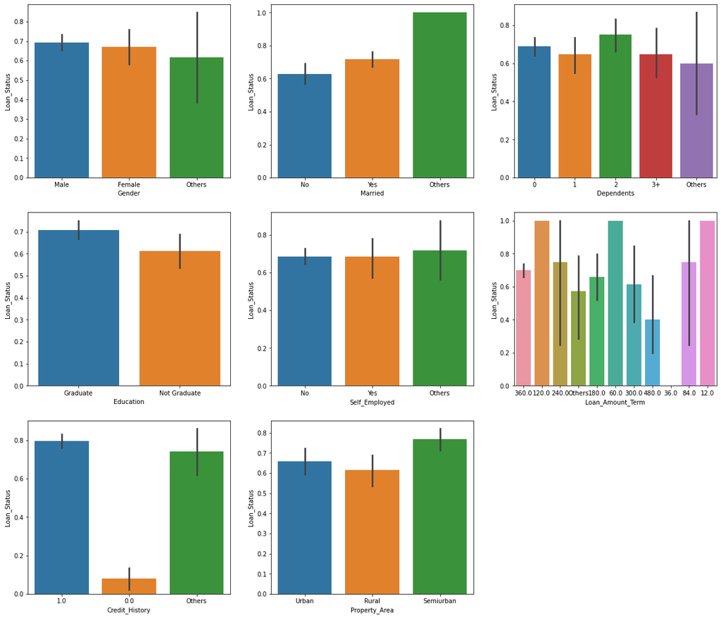

```python
plt.figure(figsize=(20,30))
plotnumber = 1
for i in data.columns.drop(['Loan_ID','ApplicantIncome','CoapplicantIncome','LoanAmount','Loan_Status']):
    plt.subplot(5,3,plotnumber)
    sns.barplot(x = str(i) , y = 'Loan_Status', data = data)
    plotnumber += 1
```

```python
data.Loan_Amount_Term.replace('Others',300, inplace = True)
```

```python
data.Gender = data.Gender.map({'Others' : 0, 'Female' : 1,'Male':2})
data.Married = data.Married.map({'No' : 0, 'Yes' : 1,'Others':2})
data.Dependents = data.Dependents.map({'0':3,'2': 4, '3+' : 1,'Others' : 0,'1':2})
data.Education = data.Education.map({'Graduate' : 1, 'Not Graduate' : 0})
data.Self_Employed = data.Self_Employed.map({'Yes' : 0, 'No' : 1,'Others' : 2})
data.Credit_History = data.Credit_History.map({float(0) : 0, 'Others' : 1,float(1) : 2})
data.Property_Area = data.Property_Area.map({'Rural' : 0, 'Urban' : 1, 'Semiurban':2})
```

```python
data.isnull().sum()
```

```
Loan_ID               0
Gender                0
Married               0
Dependents            0
Education             0
Self_Employed         0
ApplicantIncome       0
CoapplicantIncome     0
LoanAmount           22
Loan_Amount_Term      0
Credit_History        0
Property_Area         0
Loan_Status           0
dtype: int64
```

```python
data
```

|  | Loan_ID | Gender | Married | Dependents | Education | Self_Employed | ApplicantIncome | CoapplicantIncome | LoanAmount | Loan_Amount_Term | Credit_History | Property_Area | Loan_Status |
| --- | --- | --- | --- | --- | --- | --- | --- | --- | --- | --- | --- | --- | --- |
| 0 | LP001002 | 2 | 0 | 3 | 1 | 1 | 5849 | 0.0 | NaN | 360.0 | 2 | 1 | 1 |
| 1 | LP001003 | 2 | 1 | 2 | 1 | 1 | 4583 | 1508.0 | 128.0 | 360.0 | 2 | 0 | 0 |
| 2 | LP001005 | 2 | 1 | 3 | 1 | 0 | 3000 | 0.0 | 66.0 | 360.0 | 2 | 1 | 1 |
| 3 | LP001006 | 2 | 1 | 3 | 0 | 1 | 2583 | 2358.0 | 120.0 | 360.0 | 2 | 1 | 1 |
| 4 | LP001008 | 2 | 0 | 3 | 1 | 1 | 6000 | 0.0 | 141.0 | 360.0 | 2 | 1 | 1 |
| ... | ... | ... | ... | ... | ... | ... | ... | ... | ... | ... | ... | ... | ... |
| 609 | LP002978 | 1 | 0 | 3 | 1 | 1 | 2900 | 0.0 | 71.0 | 360.0 | 2 | 0 | 1 |
| 610 | LP002979 | 2 | 1 | 1 | 1 | 1 | 4106 | 0.0 | 40.0 | 180.0 | 2 | 0 | 1 |
| 611 | LP002983 | 2 | 1 | 2 | 1 | 1 | 8072 | 240.0 | 253.0 | 360.0 | 2 | 1 | 1 |
| 612 | LP002984 | 2 | 1 | 4 | 1 | 1 | 7583 | 0.0 | 187.0 | 360.0 | 2 | 1 | 1 |
| 613 | LP002990 | 1 | 0 | 3 | 1 | 0 | 4583 | 0.0 | 133.0 | 360.0 | 0 | 2 | 0 |

614 rows × 13 columns

```python
categorical = [i for i in data.columns if len(data[str(i)].unique()) < 20 and i != 'Loan_Status']
numerical = [i for i in data.columns if i not in categorical and i !='Loan_Status' and data[i].dtype != 'object']
```

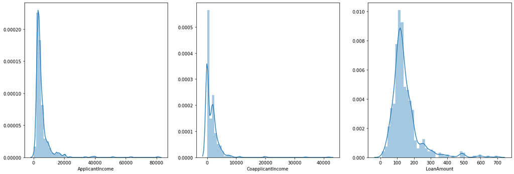

```python
plt.figure(figsize=(20,30))
plotnumber = 1
for i in numerical:
    plt.subplot(4,3,plotnumber)
    sns.distplot(data[str(i)])
    plotnumber += 1
```

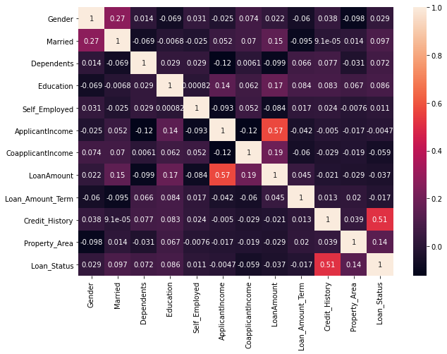

```python
# The heatmap gives us the visual representation of correlation between variables.
plt.figure(figsize = (10,7))
sns.heatmap(data.corr(), annot= True);
```

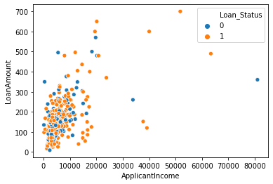

```python
sns.scatterplot(x= data.ApplicantIncome , y = data.LoanAmount, hue = data.Loan_Status, data = data )
```

```python
pd.crosstab(data.Credit_History,data.Loan_Status)
```

| Loan_Status Credit_History | 0 | 1 |
| --- | --- | --- |
| 0 | 82 | 7 |
| 1 | 13 | 37 |
| 2 | 97 | 378 |

```python
m1 = data[data.LoanAmount.isnull() == False]
m1
```

|  | Loan_ID | Gender | Married | Dependents | Education | Self_Employed | ApplicantIncome | CoapplicantIncome | LoanAmount | Loan_Amount_Term | Credit_History | Property_Area | Loan_Status |
| --- | --- | --- | --- | --- | --- | --- | --- | --- | --- | --- | --- | --- | --- |
| 1 | LP001003 | 2 | 1 | 2 | 1 | 1 | 4583 | 1508.0 | 128.0 | 360.0 | 2 | 0 | 0 |
| 2 | LP001005 | 2 | 1 | 3 | 1 | 0 | 3000 | 0.0 | 66.0 | 360.0 | 2 | 1 | 1 |
| 3 | LP001006 | 2 | 1 | 3 | 0 | 1 | 2583 | 2358.0 | 120.0 | 360.0 | 2 | 1 | 1 |
| 4 | LP001008 | 2 | 0 | 3 | 1 | 1 | 6000 | 0.0 | 141.0 | 360.0 | 2 | 1 | 1 |
| 5 | LP001011 | 2 | 1 | 4 | 1 | 0 | 5417 | 4196.0 | 267.0 | 360.0 | 2 | 1 | 1 |
| ... | ... | ... | ... | ... | ... | ... | ... | ... | ... | ... | ... | ... | ... |
| 609 | LP002978 | 1 | 0 | 3 | 1 | 1 | 2900 | 0.0 | 71.0 | 360.0 | 2 | 0 | 1 |
| 610 | LP002979 | 2 | 1 | 1 | 1 | 1 | 4106 | 0.0 | 40.0 | 180.0 | 2 | 0 | 1 |
| 611 | LP002983 | 2 | 1 | 2 | 1 | 1 | 8072 | 240.0 | 253.0 | 360.0 | 2 | 1 | 1 |
| 612 | LP002984 | 2 | 1 | 4 | 1 | 1 | 7583 | 0.0 | 187.0 | 360.0 | 2 | 1 | 1 |
| 613 | LP002990 | 1 | 0 | 3 | 1 | 0 | 4583 | 0.0 | 133.0 | 360.0 | 0 | 2 | 0 |

592 rows × 13 columns

```python
m2 = data[data.LoanAmount.isnull()]
m2
```

|  | Loan_ID | Gender | Married | Dependents | Education | Self_Employed | ApplicantIncome | CoapplicantIncome | LoanAmount | Loan_Amount_Term | Credit_History | Property_Area | Loan_Status |
| --- | --- | --- | --- | --- | --- | --- | --- | --- | --- | --- | --- | --- | --- |
| 0 | LP001002 | 2 | 0 | 3 | 1 | 1 | 5849 | 0.0 | NaN | 360.0 | 2 | 1 | 1 |
| 35 | LP001106 | 2 | 1 | 3 | 1 | 1 | 2275 | 2067.0 | NaN | 360.0 | 2 | 1 | 1 |
| 63 | LP001213 | 2 | 1 | 2 | 1 | 1 | 4945 | 0.0 | NaN | 360.0 | 0 | 0 | 0 |
| 81 | LP001266 | 2 | 1 | 2 | 1 | 0 | 2395 | 0.0 | NaN | 360.0 | 2 | 2 | 1 |
| 95 | LP001326 | 2 | 0 | 3 | 1 | 2 | 6782 | 0.0 | NaN | 360.0 | 1 | 1 | 0 |
| 102 | LP001350 | 2 | 1 | 0 | 1 | 1 | 13650 | 0.0 | NaN | 360.0 | 2 | 1 | 1 |
| 103 | LP001356 | 2 | 1 | 3 | 1 | 1 | 4652 | 3583.0 | NaN | 360.0 | 2 | 2 | 1 |
| 113 | LP001392 | 1 | 0 | 2 | 1 | 0 | 7451 | 0.0 | NaN | 360.0 | 2 | 2 | 1 |
| 127 | LP001449 | 2 | 0 | 3 | 1 | 1 | 3865 | 1640.0 | NaN | 360.0 | 2 | 0 | 1 |
| 202 | LP001682 | 2 | 1 | 1 | 0 | 1 | 3992 | 0.0 | NaN | 180.0 | 2 | 1 | 0 |
| 284 | LP001922 | 2 | 1 | 3 | 1 | 1 | 20667 | 0.0 | NaN | 360.0 | 2 | 0 | 0 |
| 305 | LP001990 | 2 | 0 | 3 | 0 | 1 | 2000 | 0.0 | NaN | 360.0 | 2 | 1 | 0 |
| 322 | LP002054 | 2 | 1 | 4 | 0 | 1 | 3601 | 1590.0 | NaN | 360.0 | 2 | 0 | 1 |
| 338 | LP002113 | 1 | 0 | 1 | 0 | 1 | 1830 | 0.0 | NaN | 360.0 | 0 | 1 | 0 |
| 387 | LP002243 | 2 | 1 | 3 | 0 | 1 | 3010 | 3136.0 | NaN | 360.0 | 0 | 1 | 0 |
| 435 | LP002393 | 1 | 2 | 0 | 1 | 1 | 10047 | 0.0 | NaN | 240.0 | 2 | 2 | 1 |
| 437 | LP002401 | 2 | 1 | 3 | 1 | 1 | 2213 | 1125.0 | NaN | 360.0 | 2 | 1 | 1 |
| 479 | LP002533 | 2 | 1 | 4 | 1 | 1 | 2947 | 1603.0 | NaN | 360.0 | 2 | 1 | 0 |
| 524 | LP002697 | 2 | 0 | 3 | 1 | 1 | 4680 | 2087.0 | NaN | 360.0 | 2 | 2 | 0 |
| 550 | LP002778 | 2 | 1 | 4 | 1 | 0 | 6633 | 0.0 | NaN | 360.0 | 0 | 0 | 0 |
| 551 | LP002784 | 2 | 1 | 2 | 0 | 1 | 2492 | 2375.0 | NaN | 360.0 | 2 | 0 | 1 |
| 605 | LP002960 | 2 | 1 | 3 | 0 | 1 | 2400 | 3800.0 | NaN | 180.0 | 2 | 1 | 0 |

```python
from sklearn.linear_model  import LinearRegression
from sklearn.tree import DecisionTreeRegressor
from sklearn.ensemble import RandomForestRegressor
from xgboost import XGBRegressor
from sklearn.neighbors import KNeighborsRegressor
from sklearn.svm import SVR
from sklearn.model_selection import train_test_split

x_train,x_test,y_train,y_test = train_test_split(m1[['Married','Education','ApplicantIncome','CoapplicantIncome']],m1[['LoanAmount']],test_size=0.2, random_state= 35)

for i in [LinearRegression(), DecisionTreeRegressor(), RandomForestRegressor(), XGBRegressor(), KNeighborsRegressor(), SVR()]:
    i.fit(x_train,y_train)
    print(i, ' score: ', i.score(x_test,y_test), '\n')
```

```
LinearRegression()  score:  0.21226007631534283

DecisionTreeRegressor()  score:  0.16010034552618357

RandomForestRegressor()  score:  0.505578936632125
```

```
XGBRegressor(base_score=0.5, booster='gbtree', colsample_bylevel=1,
             colsample_bynode=1, colsample_bytree=1, gamma=0, gpu_id=-1,
             importance_type='gain', interaction_constraints='',
             learning_rate=0.300000012, max_delta_step=0, max_depth=6,
             min_child_weight=1, missing=nan, monotone_constraints='()',
             n_estimators=100, n_jobs=0, num_parallel_tree=1, random_state=0,
             reg_alpha=0, reg_lambda=1, scale_pos_weight=1, subsample=1,
             tree_method='exact', validate_parameters=1, verbosity=None)  score:  0.31448959100593343

KNeighborsRegressor()  score:  0.5587468947020553

SVR()  score:  0.1341446953077322
```

```python
# KNN performs well, so we use it to find missing value.
```

```python
k1 = KNeighborsRegressor()
k1.fit(x_train,y_train)
k1.score(x_test,y_test)
```

```
0.5587468947020553
```

```python
parameter ={'algorithm' : ['ball_tree', 'kd_tree', 'brute'],
            'leaf_size' : np.arange(15,35,1),
            'n_neighbors' : np.arange(1,25,1),
            'p' : [1,2],
            'weights' : ['uniform', 'distance']
            }
from sklearn.model_selection import RandomizedSearchCV
rand_search = RandomizedSearchCV(estimator=k1,param_distributions=parameter,cv =5, verbose =1, n_jobs=-1,n_iter=15000)
rand_search.fit(x_train,y_train)
k1 = KNeighborsRegressor(weights = rand_search.best_params_['weights'],p = rand_search.best_params_['p'] ,algorithm = rand_search.best_params_['algorithm'],leaf_size = rand_search.best_params_['leaf_size'],n_neighbors = rand_search.best_params_['n_neighbors'])
k1.fit(x_train,y_train)
```

```
Fitting 5 folds for each of 5760 candidates, totalling 28800 fits
```

```
[Parallel(n_jobs=-1)]: Done  34 tasks      | elapsed:    3.5s
[Parallel(n_jobs=-1)]: Done 1560 tasks      | elapsed:    7.4s
[Parallel(n_jobs=-1)]: Done 5560 tasks      | elapsed:   19.5s
[Parallel(n_jobs=-1)]: Done 11160 tasks      | elapsed:   35.7s
[Parallel(n_jobs=-1)]: Done 18360 tasks      | elapsed:   56.3s
[Parallel(n_jobs=-1)]: Done 27160 tasks      | elapsed:  1.4min
[Parallel(n_jobs=-1)]: Done 28800 out of 28800 | elapsed:  1.4min finished
```

```
KNeighborsRegressor(algorithm='brute', leaf_size=15, n_neighbors=8, p=1)
```

```python
k1.score(x_test,y_test)
```

```
0.6073190551866866
```

```python
m2.LoanAmount = k1.predict(m2[['Married','Education','ApplicantIncome','CoapplicantIncome']])
```

```python
m2
```

|  | Loan_ID | Gender | Married | Dependents | Education | Self_Employed | ApplicantIncome | CoapplicantIncome | LoanAmount | Loan_Amount_Term | Credit_History | Property_Area | Loan_Status |
| --- | --- | --- | --- | --- | --- | --- | --- | --- | --- | --- | --- | --- | --- |
| 0 | LP001002 | 2 | 0 | 3 | 1 | 1 | 5849 | 0.0 | 153.875 | 360.0 | 2 | 1 | 1 |
| 35 | LP001106 | 2 | 1 | 3 | 1 | 1 | 2275 | 2067.0 | 105.625 | 360.0 | 2 | 1 | 1 |
| 63 | LP001213 | 2 | 1 | 2 | 1 | 1 | 4945 | 0.0 | 111.875 | 360.0 | 0 | 0 | 0 |
| 81 | LP001266 | 2 | 1 | 2 | 1 | 0 | 2395 | 0.0 | 62.500 | 360.0 | 2 | 2 | 1 |
| 95 | LP001326 | 2 | 0 | 3 | 1 | 2 | 6782 | 0.0 | 134.875 | 360.0 | 1 | 1 | 0 |
| 102 | LP001350 | 2 | 1 | 0 | 1 | 1 | 13650 | 0.0 | 226.625 | 360.0 | 2 | 1 | 1 |
| 103 | LP001356 | 2 | 1 | 3 | 1 | 1 | 4652 | 3583.0 | 169.375 | 360.0 | 2 | 2 | 1 |
| 113 | LP001392 | 1 | 0 | 2 | 1 | 0 | 7451 | 0.0 | 160.375 | 360.0 | 2 | 2 | 1 |
| 127 | LP001449 | 2 | 0 | 3 | 1 | 1 | 3865 | 1640.0 | 136.250 | 360.0 | 2 | 0 | 1 |
| 202 | LP001682 | 2 | 1 | 1 | 0 | 1 | 3992 | 0.0 | 99.375 | 180.0 | 2 | 1 | 0 |
| 284 | LP001922 | 2 | 1 | 3 | 1 | 1 | 20667 | 0.0 | 418.750 | 360.0 | 2 | 0 | 0 |
| 305 | LP001990 | 2 | 0 | 3 | 0 | 1 | 2000 | 0.0 | 69.000 | 360.0 | 2 | 1 | 0 |
| 322 | LP002054 | 2 | 1 | 4 | 0 | 1 | 3601 | 1590.0 | 115.500 | 360.0 | 2 | 0 | 1 |
| 338 | LP002113 | 1 | 0 | 1 | 0 | 1 | 1830 | 0.0 | 59.250 | 360.0 | 0 | 1 | 0 |
| 387 | LP002243 | 2 | 1 | 3 | 0 | 1 | 3010 | 3136.0 | 122.500 | 360.0 | 0 | 1 | 0 |
| 435 | LP002393 | 1 | 2 | 0 | 1 | 1 | 10047 | 0.0 | 195.625 | 240.0 | 2 | 2 | 1 |
| 437 | LP002401 | 2 | 1 | 3 | 1 | 1 | 2213 | 1125.0 | 86.125 | 360.0 | 2 | 1 | 1 |
| 479 | LP002533 | 2 | 1 | 4 | 1 | 1 | 2947 | 1603.0 | 123.500 | 360.0 | 2 | 1 | 0 |
| 524 | LP002697 | 2 | 0 | 3 | 1 | 1 | 4680 | 2087.0 | 151.625 | 360.0 | 2 | 2 | 0 |
| 550 | LP002778 | 2 | 1 | 4 | 1 | 0 | 6633 | 0.0 | 152.500 | 360.0 | 0 | 0 | 0 |
| 551 | LP002784 | 2 | 1 | 2 | 0 | 1 | 2492 | 2375.0 | 128.125 | 360.0 | 2 | 0 | 1 |
| 605 | LP002960 | 2 | 1 | 3 | 0 | 1 | 2400 | 3800.0 | 135.125 | 180.0 | 2 | 1 | 0 |

```python
m = pd.concat([m1,m2])
m = m.sort_index()
```

```python
m.isnull().sum()
```

```
Loan_ID              0
Gender               0
Married              0
Dependents           0
Education            0
Self_Employed        0
ApplicantIncome      0
CoapplicantIncome    0
LoanAmount           0
Loan_Amount_Term     0
Credit_History       0
Property_Area        0
Loan_Status          0
dtype: int64
```

```python
m
```

|  | Loan_ID | Gender | Married | Dependents | Education | Self_Employed | ApplicantIncome | CoapplicantIncome | LoanAmount | Loan_Amount_Term | Credit_History | Property_Area | Loan_Status |
| --- | --- | --- | --- | --- | --- | --- | --- | --- | --- | --- | --- | --- | --- |
| 0 | LP001002 | 2 | 0 | 3 | 1 | 1 | 5849 | 0.0 | 153.875 | 360.0 | 2 | 1 | 1 |
| 1 | LP001003 | 2 | 1 | 2 | 1 | 1 | 4583 | 1508.0 | 128.000 | 360.0 | 2 | 0 | 0 |
| 2 | LP001005 | 2 | 1 | 3 | 1 | 0 | 3000 | 0.0 | 66.000 | 360.0 | 2 | 1 | 1 |
| 3 | LP001006 | 2 | 1 | 3 | 0 | 1 | 2583 | 2358.0 | 120.000 | 360.0 | 2 | 1 | 1 |
| 4 | LP001008 | 2 | 0 | 3 | 1 | 1 | 6000 | 0.0 | 141.000 | 360.0 | 2 | 1 | 1 |
| ... | ... | ... | ... | ... | ... | ... | ... | ... | ... | ... | ... | ... | ... |
| 609 | LP002978 | 1 | 0 | 3 | 1 | 1 | 2900 | 0.0 | 71.000 | 360.0 | 2 | 0 | 1 |
| 610 | LP002979 | 2 | 1 | 1 | 1 | 1 | 4106 | 0.0 | 40.000 | 180.0 | 2 | 0 | 1 |
| 611 | LP002983 | 2 | 1 | 2 | 1 | 1 | 8072 | 240.0 | 253.000 | 360.0 | 2 | 1 | 1 |
| 612 | LP002984 | 2 | 1 | 4 | 1 | 1 | 7583 | 0.0 | 187.000 | 360.0 | 2 | 1 | 1 |
| 613 | LP002990 | 1 | 0 | 3 | 1 | 0 | 4583 | 0.0 | 133.000 | 360.0 | 0 | 2 | 0 |

614 rows × 13 columns

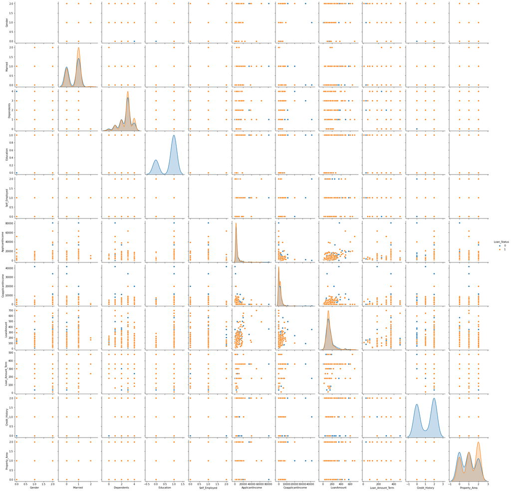

```python
sns.pairplot(m, hue = 'Loan_Status')
```

```python
X = m.drop(['Loan_Status','Loan_ID'], axis =1)
Y = m['Loan_Status']
```

```python
categorical = [i for i in X.columns if len(X[str(i)].unique()) < 20 and i != 'Loan_Status']
numerical = [i for i in X.columns if i not in categorical and i !='Loan_Status']
```

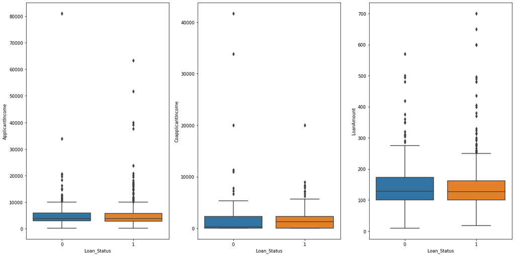

```python
j = 1
plt.figure(figsize=(20,10))
for i in numerical:
    plt.subplot(1,3,j)
    sns.boxplot(Y,X[i])
    j += 1
```

```python
numerical
```

```
['ApplicantIncome', 'CoapplicantIncome', 'LoanAmount']
```

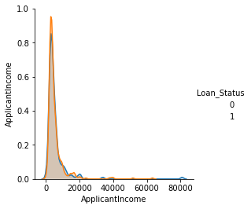

```python
sns.pairplot(pd.DataFrame([m.ApplicantIncome,m.Loan_Status]).T, hue = 'Loan_Status', size=3.5)
```

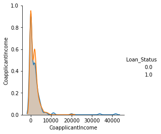

```python
sns.pairplot(pd.DataFrame([m.CoapplicantIncome,m.Loan_Status]).T, hue = 'Loan_Status', size=3.5)
```

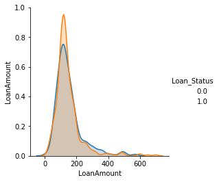

```python
sns.pairplot(pd.DataFrame([m.LoanAmount,m.Loan_Status]).T, hue = 'Loan_Status', size=3.5)
```

```python
# Test to check the equality of variance
import scipy.stats as stats
for i in numerical:
    print(i,': ',stats.levene(X[i][Y == 0],X[i][Y == 1]))
```

```
ApplicantIncome :  LeveneResult(statistic=0.041357686256057014, pvalue=0.8389166546345368)
CoapplicantIncome :  LeveneResult(statistic=4.879592536865541, pvalue=0.027545734362092743)
LoanAmount :  LeveneResult(statistic=0.9853176272007302, pvalue=0.3212817799734987)
```

Since pValue for CoapplicantIncome < 0.05, CoapplicantIncome has significat difference in variance for Different Loan Status.

```python
# To test the Equality of means
import scipy.stats as stats
for i in numerical:
    print(i,': ',stats.f_oneway(X[i][Y == 0],X[i][Y == 1]))
```

```
ApplicantIncome :  F_onewayResult(statistic=0.013574218522301744, pvalue=0.907287812130378)
CoapplicantIncome :  F_onewayResult(statistic=2.1514573558666705, pvalue=0.1429482868428829)
LoanAmount :  F_onewayResult(statistic=0.7913593827025313, pvalue=0.37403893199772054)
```

```python
# Chi-Square test for Checking of Independence of variables.
from scipy import stats
print("H0 : Assume there is no dependence between two variable")
print("H1 : Assume there is dependence between two variable")
var1 = []
var2 = []
chi2 = []
df = []
p = []
d = []
h = []
for i in categorical:
            cross_tab = pd.crosstab(X[str(i)],Y)
            chi2_stat, p_val, dof, ex = stats.chi2_contingency(cross_tab)
            var1.append(i)
            var2.append('Loan_Status')
            chi2.append(chi2_stat)
            df.append(dof)
            p.append(p_val)
            if p_val > 0.05:
                d.append('Independent')
                h.append('Accepted')
            else:
                d.append('Dependent')
                h.append('Rejected')
a = pd.DataFrame([var1,var2,chi2,df,p,d,h],index=['variable 1','variable 2','Chi2 Value','DOF','P Value','Decison (5% LOS)','Null Hypothesis']).T
a
```

```
H0 : Assume there is no dependence between two variable
H1 : Assume there is dependence between two variable
```

|  | variable 1 | variable 2 | Chi2 Value | DOF | P Value | Decison (5% LOS) | Null Hypothesis |
| --- | --- | --- | --- | --- | --- | --- | --- |
| 0 | Gender | Loan_Status | 0.555896 | 2 | 0.757336 | Independent | Accepted |
| 1 | Married | Loan_Status | 6.25487 | 2 | 0.0438302 | Dependent | Rejected |
| 2 | Dependents | Loan_Status | 3.69143 | 4 | 0.449374 | Independent | Accepted |
| 3 | Education | Loan_Status | 4.09149 | 1 | 0.0430996 | Dependent | Rejected |
| 4 | Self_Employed | Loan_Status | 0.158498 | 2 | 0.92381 | Independent | Accepted |
| 5 | Loan_Amount_Term | Loan_Status | 14.781 | 9 | 0.0971299 | Independent | Accepted |
| 6 | Credit_History | Loan_Status | 180.066 | 2 | 7.92616e-40 | Dependent | Rejected |
| 7 | Property_Area | Loan_Status | 12.2976 | 2 | 0.00213602 | Dependent | Rejected |

```python
X = m[['Married','Education','Property_Area','CoapplicantIncome','Credit_History']]
Y = m['Loan_Status']
```

```python
from sklearn.model_selection import train_test_split
x_train,x_test,y_train,y_test = train_test_split(X,Y, test_size= 0.25, random_state = 35)
```

```python
from sklearn.preprocessing import StandardScaler
```

```python
scalar = StandardScaler()
x_train = scalar.fit_transform(x_train)
x_test = scalar.transform(x_test)
```

```python
X_scaled = scalar.fit_transform(X)
```

In the Banking industry giving loans is the primary source of making money but at the same time if your repayment rate is not good you will not make any profit, rather you will risk huge losses. Banks don’t want to lose good customers and at the same point in time, they don’t want to acquire bad customers. In this scenario, both the false positives and false negatives become very important to measure. This Problem is related to Prediction of Loan Approval, So our main objective is to build a model that can correctly predict whether a customer gets loan or not. We should give more priority to `maximize Recall or Sensitivity` and at the same time we should maximize `Precision` or we can say we should minimize the False Positive Rate.

#### Recall or Sensitivity

The mathematical formula is:

**Recall**= $ \frac{ TP}{(TP+FN)} $

Or, as the name suggests, it is a measure of: from the total number of positive results how many positives were correctly predicted by the model.

### Precision

Precision is a measure of amongst all the positive predictions, how many of them were actually positive. Mathematically,

Precision=$ \frac {TP}{(TP+FP)} $

#### AUC(Area Under Curve)

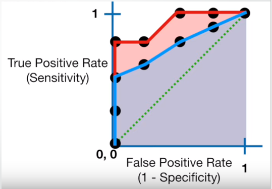

- It helps us to choose the best model amongst the models for which we have plotted the ROC curves
- The best model is the one which encompasses the maximum area under it.
- In the adjacent diagram, amongst the two curves, the model that resulted in the red one should be chosen as it clearly covers more area than the blue one

In order to do comparison among the models, we use AUC (Area under curve) of Receiver Operator Characteristic, The model with Higher AUC would be selected.

```python
# Creating a Function for metrics of model
from sklearn.metrics import confusion_matrix, roc_auc_score
def score(model, x_test, y_test):
    y_pred = model.predict(x_test)

    conf_mat = confusion_matrix(y_test,y_pred)
    true_positive = conf_mat[1][1]
    false_positive = conf_mat[0][1]
    false_negative = conf_mat[1][0]
    true_negative = conf_mat[0][0]

    Accuracy = (true_positive+true_negative)/(true_positive+true_negative+false_negative+false_positive)
    Precision = true_positive/(true_positive+false_positive)
    Recall = true_positive/(true_positive+false_negative)
    F1_Score = 2*(Recall * Precision) / (Recall + Precision)
    auc = roc_auc_score(y_test, y_pred)

    print('Model Name\t',model)
    print('Accuracy\t {:.4f}'.format(Accuracy))
    print('Precision\t {:.4f}'.format(Precision))
    print('Recall\t\t {:.4f}'.format(Recall))
    print('F1 Score\t {:.4f}'.format(F1_Score))
    print('AUC\t\t {:.4f}'.format(auc))
```

```python
# Creating a function for Cross Validation
from numpy import mean
from numpy import std
from sklearn.metrics import recall_score
from sklearn.model_selection import KFold
from sklearn.model_selection import cross_val_score
cv = KFold(n_splits=10, random_state=1, shuffle=True)

def kcross(model,X,Y):
    scores = cross_val_score(model, X, Y, scoring='accuracy', cv=cv, n_jobs=-1)
    print('Accuracy: %.3f (%.3f)' % (mean(scores), std(scores)))
    scores = cross_val_score(model, X, Y, scoring='precision', cv=cv, n_jobs=-1)
    print('Precision: %.3f (%.3f)' % (mean(scores), std(scores)))
    scores = cross_val_score(model, X, Y, scoring='recall', cv=cv, n_jobs=-1)
    print('Recall: %.3f (%.3f)' % (mean(scores), std(scores)))
    scores = cross_val_score(model, X, Y, scoring='f1', cv=cv, n_jobs=-1)
    print('F1 Score: %.3f (%.3f)' % (mean(scores), std(scores)))
    scores = cross_val_score(model, X, Y, scoring='roc_auc', cv=cv, n_jobs=-1)
    print('AUC: %.3f (%.3f)' % (mean(scores), std(scores)))
```

# Logistic Regression

```python
from sklearn.linear_model  import LogisticRegression
# create model
model = LogisticRegression()
model.fit(x_train,y_train)
score(model,x_test,y_test)
```

```
Model Name	 LogisticRegression()
Accuracy	 0.7857
Precision	 0.7879
Recall		 0.9541
F1 Score	 0.8631
AUC		 0.6660
```

```python
kcross(model,X_scaled,Y)
```

```
Accuracy: 0.788 (0.060)
Precision: 0.796 (0.060)
Recall: 0.933 (0.035)
F1 Score: 0.858 (0.041)
AUC: 0.772 (0.082)
```

```python
from scipy.stats import uniform
parameter = {'C' : uniform(loc = 0,scale =4), 'penalty' : ['l1','l2','elasticnet']}

from sklearn.model_selection import RandomizedSearchCV
rand_search = RandomizedSearchCV(estimator=model,param_distributions=parameter,scoring='roc_auc',cv =5, verbose =1, n_jobs=-1,n_iter=1000)
rand_search.fit(x_train,y_train)
model = LogisticRegression(C = rand_search.best_params_['C'],penalty = rand_search.best_params_['penalty'],solver = 'liblinear' )
model.fit(x_train,y_train)
```

```
Fitting 5 folds for each of 1000 candidates, totalling 5000 fits
```

```
[Parallel(n_jobs=-1)]: Using backend LokyBackend with 8 concurrent workers.
[Parallel(n_jobs=-1)]: Done  56 tasks      | elapsed:    0.1s
[Parallel(n_jobs=-1)]: Done 4752 tasks      | elapsed:    3.9s
[Parallel(n_jobs=-1)]: Done 5000 out of 5000 | elapsed:    4.1s finished
```

```
LogisticRegression(C=0.017666271167563696, solver='liblinear')
```

```python
score(model,x_test,y_test)
```

```
Model Name	 LogisticRegression(C=0.017666271167563696, solver='liblinear')
Accuracy	 0.7857
Precision	 0.7879
Recall		 0.9541
F1 Score	 0.8631
AUC		 0.6660
```

```python
kcross(model,X_scaled,Y)
```

```
Accuracy: 0.788 (0.063)
Precision: 0.795 (0.061)
Recall: 0.936 (0.037)
F1 Score: 0.859 (0.043)
AUC: 0.773 (0.082)
```

# Decision Tree

```python
from sklearn.tree import DecisionTreeClassifier
# create model
model = DecisionTreeClassifier()
model.fit(x_train,y_train)
score(model,x_test,y_test)
```

```
Model Name	 DecisionTreeClassifier()
Accuracy	 0.7013
Precision	 0.7692
Recall		 0.8257
F1 Score	 0.7965
AUC		 0.6128
```

```python
kcross(model,X_scaled,Y)
```

```
Accuracy: 0.735 (0.039)
Precision: 0.789 (0.050)
Recall: 0.845 (0.057)
F1 Score: 0.814 (0.028)
AUC: 0.698 (0.040)
```

```python
model.feature_importances_
```

```
array([0.03596799, 0.04523219, 0.04392453, 0.40269217, 0.47218312])
```

```python
parameter = {
    'criterion': ['gini', 'entropy'],
    'max_depth' : range(2,32,1),
    'min_samples_leaf' : range(1,10,1),
    'min_samples_split': range(2,10,1),
    'splitter' : ['best', 'random'],

}
from sklearn.model_selection import RandomizedSearchCV
rand_search = RandomizedSearchCV(estimator=model,param_distributions=parameter,scoring='roc_auc',cv =5, verbose =1, n_jobs=-1,n_iter=10000)
rand_search.fit(x_train,y_train)
model = DecisionTreeClassifier(criterion = rand_search.best_params_['criterion'],max_depth = rand_search.best_params_['max_depth'],min_samples_leaf = rand_search.best_params_['min_samples_leaf'],min_samples_split = rand_search.best_params_['min_samples_split'],splitter = rand_search.best_params_['splitter'])
model.fit(x_train,y_train)
```

```
Fitting 5 folds for each of 8640 candidates, totalling 43200 fits
```

```
[Parallel(n_jobs=-1)]: Done  56 tasks      | elapsed:    0.1s
[Parallel(n_jobs=-1)]: Done 3824 tasks      | elapsed:    3.3s
[Parallel(n_jobs=-1)]: Done 11824 tasks      | elapsed:   10.2s
[Parallel(n_jobs=-1)]: Done 23024 tasks      | elapsed:   19.3s
[Parallel(n_jobs=-1)]: Done 37424 tasks      | elapsed:   31.5s
[Parallel(n_jobs=-1)]: Done 43200 out of 43200 | elapsed:   36.2s finished
```

```
DecisionTreeClassifier(criterion='entropy', max_depth=4, min_samples_leaf=3,
                       min_samples_split=8, splitter='random')
```

```python
score(model,x_test,y_test)
```

```
Model Name	 DecisionTreeClassifier(criterion='entropy', max_depth=4, min_samples_leaf=3,
                       min_samples_split=8, splitter='random')
Accuracy	 0.7987
Precision	 0.7786
Recall		 1.0000
F1 Score	 0.8755
AUC		 0.6556
```

```python
kcross(model,X_scaled,Y)
```

```
Accuracy: 0.803 (0.052)
Precision: 0.792 (0.048)
Recall: 0.974 (0.023)
F1 Score: 0.875 (0.027)
AUC: 0.714 (0.068)
```

# Random Forest

```python
from sklearn.ensemble import RandomForestClassifier
# create model
model = RandomForestClassifier()
model.fit(x_train,y_train)
score(model,x_test,y_test)
```

```
Model Name	 RandomForestClassifier()
Accuracy	 0.7403
Precision	 0.7805
Recall		 0.8807
F1 Score	 0.8276
AUC		 0.6404
```

```python
kcross(model,X_scaled,Y)
```

```
Accuracy: 0.766 (0.050)
Precision: 0.796 (0.050)
Recall: 0.887 (0.060)
F1 Score: 0.837 (0.036)
AUC: 0.748 (0.059)
```

```python
parameter = {
    "n_estimators" : [90,100,115,130],
    'criterion': ['gini', 'entropy'],
    'max_depth' : range(2,20,1),
    'min_samples_leaf' : range(1,10,1),
    'min_samples_split': range(2,10,1),

}
from sklearn.model_selection import RandomizedSearchCV
rand_search = RandomizedSearchCV(estimator=model,param_distributions=parameter,scoring='roc_auc',cv =5, verbose =1, n_jobs=-1,n_iter=500)
rand_search.fit(x_train,y_train)
model = RandomForestClassifier(n_estimators = rand_search.best_params_['n_estimators'],criterion = rand_search.best_params_['criterion'],min_samples_leaf = rand_search.best_params_['min_samples_leaf'],min_samples_split = rand_search.best_params_['min_samples_split'],max_depth = rand_search.best_params_['max_depth'])
model.fit(x_train,y_train)
```

```
Fitting 5 folds for each of 500 candidates, totalling 2500 fits
```

```
[Parallel(n_jobs=-1)]: Using backend LokyBackend with 8 concurrent workers.
[Parallel(n_jobs=-1)]: Done  34 tasks      | elapsed:    2.3s
[Parallel(n_jobs=-1)]: Done 184 tasks      | elapsed:   11.3s
[Parallel(n_jobs=-1)]: Done 434 tasks      | elapsed:   26.0s
[Parallel(n_jobs=-1)]: Done 784 tasks      | elapsed:   47.3s
[Parallel(n_jobs=-1)]: Done 1234 tasks      | elapsed:  1.2min
[Parallel(n_jobs=-1)]: Done 1784 tasks      | elapsed:  1.8min
[Parallel(n_jobs=-1)]: Done 2434 tasks      | elapsed:  2.4min
[Parallel(n_jobs=-1)]: Done 2500 out of 2500 | elapsed:  2.5min finished
```

```
RandomForestClassifier(criterion='entropy', max_depth=2, n_estimators=130)
```

```python
score(model,x_test,y_test)
```

```
Model Name	 RandomForestClassifier(criterion='entropy', max_depth=2, n_estimators=130)
Accuracy	 0.7987
Precision	 0.7786
Recall		 1.0000
F1 Score	 0.8755
AUC		 0.6556
```

```python
kcross(model,X_scaled,Y)
```

```
Accuracy: 0.810 (0.048)
Precision: 0.792 (0.050)
Recall: 0.984 (0.011)
F1 Score: 0.877 (0.031)
AUC: 0.768 (0.080)
```

# XG Boost

```python
from xgboost import XGBClassifier
# create model
model = XGBClassifier()
model.fit(x_train,y_train)
score(model,x_test,y_test)
```

```
Model Name	 XGBClassifier(base_score=0.5, booster='gbtree', colsample_bylevel=1,
              colsample_bynode=1, colsample_bytree=1, gamma=0, gpu_id=-1,
              importance_type='gain', interaction_constraints='',
              learning_rate=0.300000012, max_delta_step=0, max_depth=6,
              min_child_weight=1, missing=nan, monotone_constraints='()',
              n_estimators=100, n_jobs=0, num_parallel_tree=1, random_state=0,
              reg_alpha=0, reg_lambda=1, scale_pos_weight=1, subsample=1,
              tree_method='exact', validate_parameters=1, verbosity=None)
Accuracy	 0.7532
Precision	 0.7795
Recall		 0.9083
F1 Score	 0.8390
AUC		 0.6430
```

```python
kcross(model,X_scaled,Y)
```

```
Accuracy: 0.759 (0.059)
Precision: 0.791 (0.058)
Recall: 0.886 (0.048)
F1 Score: 0.834 (0.042)
AUC: 0.736 (0.075)
```

```python
parameter={
            'learning_rate':np.arange(0,1,0.05),
            'max_depth': [1,3,5,6,7,8,9,10,12,15],
            'n_estimators':[10,50,100,200],
            'subsample' : np.arange(0.5,1.1,0.1)
            }
from sklearn.model_selection import RandomizedSearchCV
rand_search = RandomizedSearchCV(estimator=model,param_distributions=parameter,scoring='roc_auc',cv =5, verbose =1, n_jobs=7,n_iter=500)
rand_search.fit(x_train,y_train)
model = XGBClassifier(objective = 'binary:logistic', learning_rate = rand_search.best_params_['learning_rate'],max_depth = rand_search.best_params_['max_depth'],n_estimators = rand_search.best_params_['n_estimators'],subsample = rand_search.best_params_['subsample'])
model.fit(x_train,y_train)
```

```
Fitting 5 folds for each of 500 candidates, totalling 2500 fits
```

```
[Parallel(n_jobs=7)]: Using backend LokyBackend with 7 concurrent workers.
[Parallel(n_jobs=7)]: Done  39 tasks      | elapsed:    0.7s
[Parallel(n_jobs=7)]: Done 1103 tasks      | elapsed:   13.0s
[Parallel(n_jobs=7)]: Done 2487 out of 2500 | elapsed:   25.9s remaining:    0.0s
[Parallel(n_jobs=7)]: Done 2500 out of 2500 | elapsed:   25.9s finished
```

```
XGBClassifier(base_score=0.5, booster='gbtree', colsample_bylevel=1,
              colsample_bynode=1, colsample_bytree=1, gamma=0, gpu_id=-1,
              importance_type='gain', interaction_constraints='',
              learning_rate=0.45, max_delta_step=0, max_depth=1,
              min_child_weight=1, missing=nan, monotone_constraints='()',
              n_estimators=10, n_jobs=0, num_parallel_tree=1, random_state=0,
              reg_alpha=0, reg_lambda=1, scale_pos_weight=1, subsample=0.6,
              tree_method='exact', validate_parameters=1, verbosity=None)
```

```python
score(model,x_test,y_test)
```

```
Model Name	 XGBClassifier(base_score=0.5, booster='gbtree', colsample_bylevel=1,
              colsample_bynode=1, colsample_bytree=1, gamma=0, gpu_id=-1,
              importance_type='gain', interaction_constraints='',
              learning_rate=0.45, max_delta_step=0, max_depth=1,
              min_child_weight=1, missing=nan, monotone_constraints='()',
              n_estimators=10, n_jobs=0, num_parallel_tree=1, random_state=0,
              reg_alpha=0, reg_lambda=1, scale_pos_weight=1, subsample=0.6,
              tree_method='exact', validate_parameters=1, verbosity=None)
Accuracy	 0.7987
Precision	 0.7786
Recall		 1.0000
F1 Score	 0.8755
AUC		 0.6556
```

```python
rand_search.best_params_
```

```
{'subsample': 0.6, 'n_estimators': 10, 'max_depth': 1, 'learning_rate': 0.45}
```

```python
kcross(model,X_scaled,Y)
```

```
Accuracy: 0.810 (0.048)
Precision: 0.792 (0.050)
Recall: 0.984 (0.011)
F1 Score: 0.877 (0.031)
AUC: 0.740 (0.065)
```

# KNN

```python
from sklearn.neighbors import KNeighborsClassifier
# create model
model = KNeighborsClassifier()
model.fit(x_train,y_train)
score(model,x_test,y_test)
```

```
Model Name	 KNeighborsClassifier()
Accuracy	 0.7662
Precision	 0.8017
Recall		 0.8899
F1 Score	 0.8435
AUC		 0.6783
```

```python
kcross(model,X_scaled,Y)
```

```
Accuracy: 0.751 (0.068)
Precision: 0.792 (0.060)
Recall: 0.867 (0.081)
F1 Score: 0.826 (0.055)
AUC: 0.738 (0.064)
```

```python
parameter ={'algorithm' : ['ball_tree', 'kd_tree', 'brute'],
            'leaf_size' : np.arange(15,35,1),
            'n_neighbors' : np.arange(1,25,1),
            'p' : [1,2],
            'weights' : ['uniform', 'distance']
            }
from sklearn.model_selection import RandomizedSearchCV
rand_search = RandomizedSearchCV(estimator=model,param_distributions=parameter,scoring='roc_auc',cv =5, verbose =1, n_jobs=-1,n_iter=15000)
rand_search.fit(x_train,y_train)
model = KNeighborsClassifier(weights = rand_search.best_params_['weights'],p = rand_search.best_params_['p'] ,algorithm = rand_search.best_params_['algorithm'],leaf_size = rand_search.best_params_['leaf_size'],n_neighbors = rand_search.best_params_['n_neighbors'])
model.fit(x_train,y_train)
```

```
Fitting 5 folds for each of 5760 candidates, totalling 28800 fits
```

```
[Parallel(n_jobs=-1)]: Done  59 tasks      | elapsed:    0.1s
[Parallel(n_jobs=-1)]: Done 3824 tasks      | elapsed:    5.3s
[Parallel(n_jobs=-1)]: Done 11824 tasks      | elapsed:   14.9s
[Parallel(n_jobs=-1)]: Done 23024 tasks      | elapsed:   27.5s
[Parallel(n_jobs=-1)]: Done 28800 out of 28800 | elapsed:   33.8s finished
```

```
KNeighborsClassifier(algorithm='kd_tree', leaf_size=23, n_neighbors=21, p=1)
```

```python
score(model,x_test,y_test)
```

```
Model Name	 KNeighborsClassifier(algorithm='kd_tree', leaf_size=23, n_neighbors=21, p=1)
Accuracy	 0.7987
Precision	 0.7786
Recall		 1.0000
F1 Score	 0.8755
AUC		 0.6556
```

```python
kcross(model,X_scaled,Y)
```

```
Accuracy: 0.806 (0.045)
Precision: 0.792 (0.049)
Recall: 0.977 (0.014)
F1 Score: 0.874 (0.029)
AUC: 0.752 (0.063)
```

# Naive Bayes

```python
from sklearn.naive_bayes import GaussianNB
model = GaussianNB()
model.fit(x_train,y_train)
score(model,x_test,y_test)
```

```
Model Name	 GaussianNB()
Accuracy	 0.7532
Precision	 0.7840
Recall		 0.8991
F1 Score	 0.8376
AUC		 0.6495
```

```python
kcross(model,X_scaled,Y)
```

```
Accuracy: 0.772 (0.060)
Precision: 0.800 (0.061)
Recall: 0.896 (0.040)
F1 Score: 0.844 (0.042)
AUC: 0.778 (0.081)
```

# Support Vector Classifier (SVC)

```python
from sklearn.svm import SVC
model = SVC()
model.fit(x_train,y_train)
score(model,x_test,y_test)
```

```
Model Name	 SVC()
Accuracy	 0.8052
Precision	 0.7883
Recall		 0.9908
F1 Score	 0.8780
AUC		 0.6732
```

```python
kcross(model,X_scaled,Y)
```

```
Accuracy: 0.811 (0.050)
Precision: 0.795 (0.052)
Recall: 0.981 (0.014)
F1 Score: 0.877 (0.033)
AUC: 0.729 (0.091)
```

# Stacking

```python
from sklearn.linear_model  import LogisticRegression
from sklearn.tree import DecisionTreeClassifier
from sklearn.ensemble import RandomForestClassifier
from xgboost import XGBClassifier
from sklearn.neighbors import KNeighborsClassifier
from sklearn.naive_bayes import GaussianNB
from sklearn.svm import SVC
```

```python
from sklearn.preprocessing import StandardScaler
scaler=StandardScaler()
scaled_data=scaler.fit_transform(X)
```

```python
#XG Boost
xg = XGBClassifier(subsample= 0.7999999999999999,n_estimators = 100, max_depth = 7, learning_rate = 0.05)
```

```python
#random Forest
rf = RandomForestClassifier(max_depth=9, min_samples_split=5, n_estimators=90)
```

```python
# Decision Tree
dt = DecisionTreeClassifier(criterion='entropy', max_depth=27, min_samples_leaf=3,min_samples_split=8, splitter='random')
```

```python
# Logistic Regression
lg = LogisticRegression()
```

```python
# KNN
knn = KNeighborsClassifier(algorithm='brute', leaf_size=15, n_neighbors=12, p=1)
```

```python
# SVC
svc = SVC(probability= True)
```

```python
from sklearn.model_selection import train_test_split
train,val_train,test,val_test = train_test_split(scaled_data,Y,test_size=0.5, random_state= 355)
x_train,x_test,y_train,y_test =  train_test_split(train,test,test_size=0.2, random_state= 355)
```

```python
for i in [lg, dt, rf, xg, knn, svc]:
    i.fit(x_train,y_train)
    print(i, ' score: ', i.score(x_test,y_test), '\n')
```

```
LogisticRegression()  score:  0.8709677419354839

DecisionTreeClassifier(criterion='entropy', max_depth=27, min_samples_leaf=3,
                       min_samples_split=8, splitter='random')  score:  0.8709677419354839

RandomForestClassifier(max_depth=9, min_samples_split=5, n_estimators=90)  score:  0.7258064516129032

XGBClassifier(base_score=0.5, booster='gbtree', colsample_bylevel=1,
              colsample_bynode=1, colsample_bytree=1, gamma=0, gpu_id=-1,
              importance_type='gain', interaction_constraints='',
              learning_rate=0.05, max_delta_step=0, max_depth=7,
              min_child_weight=1, missing=nan, monotone_constraints='()',
              n_estimators=100, n_jobs=0, num_parallel_tree=1, random_state=0,
              reg_alpha=0, reg_lambda=1, scale_pos_weight=1,
              subsample=0.7999999999999999, tree_method='exact',
              validate_parameters=1, verbosity=None)  score:  0.8548387096774194

KNeighborsClassifier(algorithm='brute', leaf_size=15, n_neighbors=12, p=1)  score:  0.8709677419354839

SVC(probability=True)  score:  0.9032258064516129
```

```python
predict_val1 = xg.predict_proba(val_train)
predict_val2 = knn.predict_proba(val_train)
predict_val3 = rf.predict_proba(val_train)
predict_val4 = svc.predict_proba(val_train)
predict_val5 = lg.predict_proba(val_train)
predict_val6 = dt.predict_proba(val_train)
predict_val = np.column_stack((predict_val1,predict_val2,predict_val3,predict_val4,predict_val5,predict_val6))
predict_val
```

```
array([[0.46230811, 0.53769189, 0.41666667, ..., 0.65025205, 0.44444444,
        0.55555556],
       [0.93849987, 0.06150015, 0.91666667, ..., 0.0647341 , 0.83333333,
        0.16666667],
       [0.41263747, 0.58736253, 0.33333333, ..., 0.77154638, 0.42857143,
        0.57142857],
       ...,
       [0.22393858, 0.77606142, 0.16666667, ..., 0.83061643, 0.21428571,
        0.78571429],
       [0.05684185, 0.94315815, 0.08333333, ..., 0.87275069, 0.        ,
        1.        ],
       [0.0714615 , 0.9285385 , 0.08333333, ..., 0.82522446, 0.21428571,
        0.78571429]])
```

```python
rand_clf = RandomForestClassifier()
rand_clf.fit(predict_val,val_test)
```

```
RandomForestClassifier()
```

```python
predict_test1 = xg.predict_proba(x_test)
predict_test2 = knn.predict_proba(x_test)
predict_test3 = rf.predict_proba(x_test)
predict_test4 = svc.predict_proba(x_test)
predict_test5 = lg.predict_proba(x_test)
predict_test6 = dt.predict_proba(x_test)
predict_test = np.column_stack((predict_test1,predict_test2,predict_test3,predict_test4,predict_test5,predict_test6))
predict_test
```

[output not shown]

[output cut: 131 more lines]

```
       [0.92210603, 0.07789399, 0.91666667, 0.08333333, 0.87783069,
        0.12216931, 0.89574061, 0.10425939, 0.91444852, 0.08555148,
        1.        , 0.        ],
       [0.29953212, 0.70046788, 0.25      , 0.75      , 0.27404644,
        0.72595356, 0.23290892, 0.76709108, 0.27030296, 0.72969704,
        0.28571429, 0.71428571],
       [0.04983628, 0.95016372, 0.08333333, 0.91666667, 0.05568519,
        0.94431481, 0.21550851, 0.78449149, 0.13055985, 0.86944015,
        0.        , 1.        ],
       [0.90932059, 0.09067941, 0.83333333, 0.16666667, 0.93911817,
        0.06088183, 0.9178394 , 0.0821606 , 0.89838852, 0.10161148,
        1.        , 0.        ],
       [0.4620412 , 0.5379588 , 0.25      , 0.75      , 0.64167203,
        0.35832797, 0.22346619, 0.77653381, 0.28553239, 0.71446761,
        0.4       , 0.6       ]])
```

```python
score(rand_clf,predict_test,y_test)
```

```
Model Name	 RandomForestClassifier()
Accuracy	 0.7903
Precision	 0.8936
Recall		 0.8400
F1 Score	 0.8660
AUC		 0.7117
```

```python
kcross(rand_clf,predict_val,val_test)
```

```
Accuracy: 0.772 (0.068)
Precision: 0.800 (0.083)
Recall: 0.899 (0.048)
F1 Score: 0.842 (0.056)
AUC: 0.704 (0.084)
```

```python
parameter = {
    "n_estimators" : np.arange(50,150,10),
    'criterion': ['gini', 'entropy'],
    'max_depth' : range(2,20,1),
    'min_samples_leaf' : range(1,10,1),
    'min_samples_split': range(2,10,1),
}
from sklearn.model_selection import RandomizedSearchCV
rand_search = RandomizedSearchCV(estimator=RandomForestClassifier(),scoring='roc_auc',param_distributions=parameter,cv =5, verbose =1, n_jobs=-1,n_iter=2000)
rand_search.fit(predict_val,val_test)
model = RandomForestClassifier(n_estimators = rand_search.best_params_['n_estimators'],criterion = rand_search.best_params_['criterion'],min_samples_leaf = rand_search.best_params_['min_samples_leaf'],min_samples_split = rand_search.best_params_['min_samples_split'],max_depth = rand_search.best_params_['max_depth'])
model.fit(predict_val,val_test)
```

```
Fitting 5 folds for each of 2000 candidates, totalling 10000 fits
```

```
[Parallel(n_jobs=-1)]: Using backend LokyBackend with 8 concurrent workers.
[Parallel(n_jobs=-1)]: Done  34 tasks      | elapsed:    1.8s
[Parallel(n_jobs=-1)]: Done 184 tasks      | elapsed:   10.4s
[Parallel(n_jobs=-1)]: Done 434 tasks      | elapsed:   23.9s
[Parallel(n_jobs=-1)]: Done 784 tasks      | elapsed:   43.9s
[Parallel(n_jobs=-1)]: Done 1234 tasks      | elapsed:  1.2min
[Parallel(n_jobs=-1)]: Done 1784 tasks      | elapsed:  1.7min
[Parallel(n_jobs=-1)]: Done 2434 tasks      | elapsed:  2.3min
[Parallel(n_jobs=-1)]: Done 3184 tasks      | elapsed:  2.9min
[Parallel(n_jobs=-1)]: Done 4034 tasks      | elapsed:  3.7min
[Parallel(n_jobs=-1)]: Done 4984 tasks      | elapsed:  4.6min
[Parallel(n_jobs=-1)]: Done 6034 tasks      | elapsed:  5.5min
[Parallel(n_jobs=-1)]: Done 7184 tasks      | elapsed:  6.5min
[Parallel(n_jobs=-1)]: Done 8434 tasks      | elapsed:  7.7min
[Parallel(n_jobs=-1)]: Done 9784 tasks      | elapsed:  8.9min
[Parallel(n_jobs=-1)]: Done 10000 out of 10000 | elapsed:  9.1min finished
```

```
RandomForestClassifier(max_depth=2, min_samples_leaf=2, min_samples_split=5,
                       n_estimators=70)
```

```python
score(model,predict_test,y_test)
```

```
Model Name	 RandomForestClassifier(max_depth=2, min_samples_leaf=2, min_samples_split=5,
                       n_estimators=70)
Accuracy	 0.9032
Precision	 0.9231
Recall		 0.9600
F1 Score	 0.9412
AUC		 0.8133
```

```python
kcross(model,predict_val,val_test)
```

```
Accuracy: 0.805 (0.078)
Precision: 0.788 (0.082)
Recall: 0.980 (0.025)
F1 Score: 0.874 (0.056)
AUC: 0.782 (0.045)
```

# Customised Stacking

```python
from sklearn.linear_model  import LogisticRegression
from sklearn.tree import DecisionTreeClassifier
from sklearn.ensemble import RandomForestClassifier
from xgboost import XGBClassifier
from sklearn.neighbors import KNeighborsClassifier
from sklearn.naive_bayes import GaussianNB
from sklearn.svm import SVC
```

```python
from sklearn.preprocessing import StandardScaler
scaler=StandardScaler()
scaled_data=scaler.fit_transform(X)
```

```python
#XG Boost
xg = XGBClassifier()
#random Forest
rf = RandomForestClassifier()
# Decision Tree
dt = DecisionTreeClassifier()
# Logistic Regression
lg = LogisticRegression()
# KNN
knn = KNeighborsClassifier()
# SVC
svc = SVC()
```

```python
from sklearn.model_selection import train_test_split
x_train, x_test, y_train, y_test = train_test_split(X, Y, test_size = 0.20, random_state = 35 )
```

```python
for j in x_train:
    for i in [lg, dt, rf, xg, knn, svc]:
        print(j)
        i.fit(pd.DataFrame(x_train[str(j)]),y_train)
        score(i,pd.DataFrame(x_test[str(j)]),y_test)
        print('\n')
```

```
Married
Model Name	 LogisticRegression()
Accuracy	 0.7317
Precision	 0.7317
Recall		 1.0000
F1 Score	 0.8451
AUC		 0.5000


Married
Model Name	 DecisionTreeClassifier()
Accuracy	 0.7317
Precision	 0.7317
Recall		 1.0000
F1 Score	 0.8451
AUC		 0.5000


Married
Model Name	 RandomForestClassifier()
Accuracy	 0.7317
Precision	 0.7317
Recall		 1.0000
F1 Score	 0.8451
AUC		 0.5000


Married
Model Name	 XGBClassifier(base_score=0.5, booster='gbtree', colsample_bylevel=1,
              colsample_bynode=1, colsample_bytree=1, gamma=0, gpu_id=-1,
              importance_type='gain', interaction_constraints='',
              learning_rate=0.300000012, max_delta_step=0, max_depth=6,
              min_child_weight=1, missing=nan, monotone_constraints='()',
              n_estimators=100, n_jobs=0, num_parallel_tree=1, random_state=0,
              reg_alpha=0, reg_lambda=1, scale_pos_weight=1, subsample=1,
              tree_method='exact', validate_parameters=1, verbosity=None)
Accuracy	 0.7317
Precision	 0.7317
Recall		 1.0000
F1 Score	 0.8451
```

[output cut: 248 more lines]

```
Model Name	 KNeighborsClassifier()
Accuracy	 0.8211
Precision	 0.8036
Recall		 1.0000
F1 Score	 0.8911
AUC		 0.6667


Credit_History
Model Name	 SVC()
Accuracy	 0.8211
Precision	 0.8036
Recall		 1.0000
F1 Score	 0.8911
AUC		 0.6667
```

```python
from sklearn.preprocessing import StandardScaler
scaler=StandardScaler()
scaled_data=scaler.fit_transform(X)
```

```python
from sklearn.model_selection import train_test_split
train,val_train,test,val_test = train_test_split(scaled_data,Y,test_size=0.5, random_state= 355)
x_train,x_test,y_train,y_test =  train_test_split(train,test,test_size=0.2, random_state= 355)
```

```python
m1 = lg.fit(pd.DataFrame(x_train[:,[3]]),y_train)
knn.fit(pd.DataFrame(x_train[:,[0,1,2,4]]),y_train)
```

```
KNeighborsClassifier()
```

```python
from scipy.stats import uniform
parameter = {'C' : uniform(loc = 0,scale =4), 'penalty' : ['l1','l2','elasticnet']}

from sklearn.model_selection import RandomizedSearchCV
rand_search = RandomizedSearchCV(estimator=lg,param_distributions=parameter,scoring='roc_auc',cv =5, verbose =1, n_jobs=-1,n_iter=1000)
rand_search.fit(pd.DataFrame(x_train[:,[3]]),y_train)
m1 = LogisticRegression(C = rand_search.best_params_['C'],penalty = rand_search.best_params_['penalty'],solver = 'liblinear' )
m1.fit(pd.DataFrame(x_train[:,[3]]),y_train)
```

```
Fitting 5 folds for each of 1000 candidates, totalling 5000 fits
```

```
[Parallel(n_jobs=-1)]: Using backend LokyBackend with 8 concurrent workers.
[Parallel(n_jobs=-1)]: Done  56 tasks      | elapsed:    0.1s
[Parallel(n_jobs=-1)]: Done 4693 tasks      | elapsed:    4.6s
[Parallel(n_jobs=-1)]: Done 5000 out of 5000 | elapsed:    4.9s finished
```

```
LogisticRegression(C=1.3540071763197212, solver='liblinear')
```

```python
parameter ={'algorithm' : ['ball_tree', 'kd_tree', 'brute'],
            'leaf_size' : np.arange(15,35,1),
            'n_neighbors' : np.arange(1,25,1),
            'p' : [1,2],
            'weights' : ['uniform', 'distance']
            }
from sklearn.model_selection import RandomizedSearchCV
rand_search = RandomizedSearchCV(estimator=knn,param_distributions=parameter,scoring='roc_auc',cv =5, verbose =1, n_jobs=-1,n_iter=15000)
rand_search.fit(pd.DataFrame(x_train[:,[0,1,2,4]]),y_train)
knn = KNeighborsClassifier(weights = rand_search.best_params_['weights'],p = rand_search.best_params_['p'] ,algorithm = rand_search.best_params_['algorithm'],leaf_size = rand_search.best_params_['leaf_size'],n_neighbors = rand_search.best_params_['n_neighbors'])
knn.fit(pd.DataFrame(x_train[:,[0,1,2,4]]),y_train)
```

```
Fitting 5 folds for each of 5760 candidates, totalling 28800 fits
```

```
[Parallel(n_jobs=-1)]: Done  56 tasks      | elapsed:    0.1s
[Parallel(n_jobs=-1)]: Done 2160 tasks      | elapsed:    3.5s
[Parallel(n_jobs=-1)]: Done 6160 tasks      | elapsed:   10.4s
[Parallel(n_jobs=-1)]: Done 11760 tasks      | elapsed:   20.6s
[Parallel(n_jobs=-1)]: Done 18960 tasks      | elapsed:   33.9s
[Parallel(n_jobs=-1)]: Done 27760 tasks      | elapsed:   49.4s
[Parallel(n_jobs=-1)]: Done 28800 out of 28800 | elapsed:   51.3s finished
```

```
KNeighborsClassifier(algorithm='kd_tree', leaf_size=25, n_neighbors=22, p=1)
```

```python
predict_val1 = m1.predict_proba(pd.DataFrame(val_train[:,[3]]))
predict_val2 = knn.predict_proba(pd.DataFrame(val_train[:,[0,1,2,4]]))

predict_val = np.column_stack((predict_val1,predict_val2))
predict_val
```

```
array([[0.34686659, 0.65313341, 0.36363636, 0.63636364],
       [0.4409346 , 0.5590654 , 0.95454545, 0.04545455],
       [0.34686659, 0.65313341, 0.22727273, 0.77272727],
       ...,
       [0.34686659, 0.65313341, 0.22727273, 0.77272727],
       [0.35603085, 0.64396915, 0.18181818, 0.81818182],
       [0.35613183, 0.64386817, 0.22727273, 0.77272727]])
```

```python
rand_clf = RandomForestClassifier()
rand_clf.fit(predict_val,val_test)
```

```
RandomForestClassifier()
```

```python
predict_test1 = m1.predict_proba(pd.DataFrame(x_test[:,[3]]))
predict_test2 = knn.predict_proba(pd.DataFrame(x_test[:,[0,1,2,4]]))


predict_test = np.column_stack((predict_test1,predict_test2))
predict_test
```

[output not shown]

```python
score(rand_clf,predict_test,y_test)
```

```
Model Name	 RandomForestClassifier()
Accuracy	 0.8065
Precision	 0.9130
Recall		 0.8400
F1 Score	 0.8750
AUC		 0.7533
```

```python
kcross(rand_clf,predict_val,val_test)
```

```
Accuracy: 0.769 (0.073)
Precision: 0.793 (0.085)
Recall: 0.922 (0.061)
F1 Score: 0.849 (0.058)
AUC: 0.720 (0.078)
```

```python
parameter = {
    "n_estimators" : np.arange(50,150,10),
    'criterion': ['gini', 'entropy'],
    'max_depth' : range(2,20,1),
    'min_samples_leaf' : range(1,10,1),
    'min_samples_split': range(2,10,1),
}
from sklearn.model_selection import RandomizedSearchCV
rand_search = RandomizedSearchCV(estimator=RandomForestClassifier(),param_distributions=parameter,scoring='roc_auc',cv =5, verbose =1, n_jobs=-1,n_iter=2000)
rand_search.fit(predict_val,val_test)
model = RandomForestClassifier(n_estimators = rand_search.best_params_['n_estimators'],criterion = rand_search.best_params_['criterion'],min_samples_leaf = rand_search.best_params_['min_samples_leaf'],min_samples_split = rand_search.best_params_['min_samples_split'],max_depth = rand_search.best_params_['max_depth'])
model.fit(predict_val,val_test)
```

```
Fitting 5 folds for each of 2000 candidates, totalling 10000 fits
```

```
[Parallel(n_jobs=-1)]: Using backend LokyBackend with 8 concurrent workers.
[Parallel(n_jobs=-1)]: Done  52 tasks      | elapsed:    2.0s
[Parallel(n_jobs=-1)]: Done 352 tasks      | elapsed:   12.5s
[Parallel(n_jobs=-1)]: Done 852 tasks      | elapsed:   32.6s
[Parallel(n_jobs=-1)]: Done 1552 tasks      | elapsed:  1.0min
[Parallel(n_jobs=-1)]: Done 2452 tasks      | elapsed:  1.7min
[Parallel(n_jobs=-1)]: Done 3552 tasks      | elapsed:  2.6min
[Parallel(n_jobs=-1)]: Done 4426 tasks      | elapsed:  3.3min
[Parallel(n_jobs=-1)]: Done 5176 tasks      | elapsed:  4.0min
[Parallel(n_jobs=-1)]: Done 6026 tasks      | elapsed:  4.7min
[Parallel(n_jobs=-1)]: Done 6976 tasks      | elapsed:  5.5min
[Parallel(n_jobs=-1)]: Done 8026 tasks      | elapsed:  6.4min
[Parallel(n_jobs=-1)]: Done 9176 tasks      | elapsed:  7.4min
[Parallel(n_jobs=-1)]: Done 10000 out of 10000 | elapsed:  8.1min finished
```

```
RandomForestClassifier(criterion='entropy', max_depth=5, min_samples_leaf=7,
                       min_samples_split=8, n_estimators=90)
```

```python
score(model,predict_test,y_test)
```

```
Model Name	 RandomForestClassifier(criterion='entropy', max_depth=5, min_samples_leaf=7,
                       min_samples_split=8, n_estimators=90)
Accuracy	 0.9032
Precision	 0.9231
Recall		 0.9600
F1 Score	 0.9412
AUC		 0.8133
```

```python
kcross(model,predict_val,val_test)
```

```
Accuracy: 0.808 (0.076)
Precision: 0.790 (0.081)
Recall: 0.986 (0.022)
F1 Score: 0.875 (0.056)
AUC: 0.738 (0.058)
```

# Conclusion

#### The Machine Learning model gives the results as follows:

```
                                      Accuracy      Precision        Recall        F1 Score          AUC
 Decision Tree                    : 0.803 (0.052)  0.792 (0.048)  0.974 (0.023)  0.875 (0.027)  0.714 (0.068)
 Support Vector Classifier (SVC)  : 0.811 (0.050)  0.795 (0.052)  0.981 (0.014)  0.877 (0.033)  0.729 (0.091)
 XG Boost                         : 0.810 (0.048)  0.792 (0.050)  0.984 (0.011)  0.877 (0.031)  0.740 (0.065)
 Customised Stacking              : 0.808 (0.076)  0.790 (0.081)  0.986 (0.022)  0.875 (0.056)  0.738 (0.058)
 KNN                              : 0.806 (0.045)  0.792 (0.049)  0.977 (0.014)  0.874 (0.029)  0.752 (0.063)
 Random Forest                    : 0.810 (0.048)  0.792 (0.050)  0.984 (0.011)  0.877 (0.031)  0.768 (0.080)
 Logistic Regression              : 0.788 (0.063)  0.795 (0.061)  0.936 (0.037)  0.859 (0.043)  0.773 (0.082)
 Naive Bayes                      : 0.772 (0.060)  0.800 (0.061)  0.896 (0.040)  0.844 (0.042)  0.778 (0.081)
 Stacking                         : 0.805 (0.078)  0.788 (0.082)  0.980 (0.025)  0.874 (0.056)  0.782 (0.045)
```

#### On the basis of above scores, It is clear that `Stacking` perform well. So, `Stacking` must be deployed for Loan Prediction dataset.